# HW 3

Author

MinyoungSo

# Assignment 3 - Text Mining

```r
library(tidyverse)
library(tidytext)
library(textdata)
library(knitr)
```

## Text Mining

On the course Github, navigate to the page for dataset pubmed (https://github.com/dmcable/BIOSTAT620W26/tree/main/data/pubmed) and download the pubmed.csv dataset.

This dataset contains 3,241 abstracts from articles collected via 5 PubMed searches. The search terms are listed in the second column, term and these will serve as the “documents.” Your job is to analyze these abstracts to find interesting insights.

```r
pubmed <- read.csv("pubmed.csv")
#dim(pubmed)
#str(pubmed)
```

### Question 1 (15 points)

**How many abstracts are associated with each search term?** The number of abstracts by search term is highest for COVID (981), followed by prostate cancer (787), preeclampsia (780), cystic fibrosis (376), and meningitis (317).

**Tokenize the abstracts and count the number of each token. Do you see anything interesting?** Except for “COVID” and “19”, the top 10 most frequent tokens are primarily stop words such as articles and other grammatical function words. “COVID” and “19” rank 8th and 9th, respectively, which is consistent with the earlier finding that COVID-related abstracts constitute the largest portion of the dataset.

**What are the 5 most common tokens for each search term?** Across search terms, the five most frequent tokens are largely stop words. In particular, “the”, “of”, and “and” are found among the top five tokens across all the search terms. The remaining tokens are also mostly stop words, except for COVID 19 and prostate cancer, where their own search terms from the disease names appear as tokens in the top five tokens.

```r
count_pubmed <- pubmed |>
  count(term, sort = TRUE)
kable(count_pubmed)
```

| term | n |
| --- | --- |
| covid | 981 |
| prostate cancer | 787 |
| preeclampsia | 780 |
| cystic fibrosis | 376 |
| meningitis | 317 |

```r
tokens <- pubmed |>
  unnest_tokens(word, abstract) # Tokenize: splits text into individual tokens,converts text to lowercase, removes punctuation, and transforms df with one-token-per-row format.

word_counts <- tokens |>
  count(word, sort = TRUE) |>
  slice(1:10)
kable(word_counts)
```

| word | n |
| --- | --- |
| the | 28126 |
| of | 24760 |
| and | 19993 |
| in | 14653 |
| to | 10920 |
| a | 8245 |
| with | 8038 |
| covid | 7275 |
| 19 | 7080 |
| is | 5649 |

```r
top_words<- tokens |>
  count(term, word, sort = TRUE) |> # counts words(tokens) in each term
  group_by(term) |>
  slice_max(n, n = 5) # cutoff in rank list
kable(top_words)
```

| term | word | n |
| --- | --- | --- |
| covid | the | 9741 |
| covid | of | 7668 |
| covid | covid | 7275 |
| covid | 19 | 7035 |
| covid | and | 6861 |
| cystic fibrosis | the | 2677 |
| cystic fibrosis | of | 2304 |
| cystic fibrosis | and | 1777 |
| cystic fibrosis | in | 1497 |
| cystic fibrosis | to | 1011 |
| meningitis | the | 2489 |
| meningitis | of | 2269 |
| meningitis | and | 1683 |
| meningitis | in | 1322 |
| meningitis | a | 830 |
| preeclampsia | the | 7119 |
| preeclampsia | of | 6837 |
| preeclampsia | and | 5255 |
| preeclampsia | in | 3869 |
| preeclampsia | to | 2651 |
| prostate cancer | the | 6100 |
| prostate cancer | of | 5682 |
| prostate cancer | and | 4417 |
| prostate cancer | cancer | 3840 |
| prostate cancer | prostate | 3832 |

### Question 2 (15 points)

**Does removing stop words change what tokens appear as the most frequent?** After stop word removal, “COVID” becomes the most frequent token, appearing 7,275 times in the NIH abstract dataset.

**What are the 5 most common tokens for each search term after removing stop words?** After removing stop words, disease names or their abbreviations rank among the top three tokens for all search terms. “patients” and “disease” appear frequently across search terms. The remaining group of tokens among the top five is search term (disease)-specific. They tend to reflect key characteristics of each condition. For example, “pandemic” appears for COVID-19, “CSF” (a body fluid used in meningitis diagnosis) for meningitis, and “women” and “pregnancy” for preeclampsia, a pregnancy-related complication.

```r
data("stop_words")

tokens_clean <- tokens |>
  anti_join(stop_words, by = "word") |> # remove the stop words
  count(word, sort = TRUE) |>
  slice(1)
kable(tokens_clean)
```

| word | n |
| --- | --- |
| covid | 7275 |

```r
top_words_clean <- tokens |>
  anti_join(stop_words, by = "word") |>
  count(term, word, sort = TRUE) |>
  group_by(term) |>
  slice_max(n, n = 5)
knitr::kable(top_words_clean)
```

| term | word | n |
| --- | --- | --- |
| covid | covid | 7275 |
| covid | 19 | 7035 |
| covid | patients | 2293 |
| covid | disease | 943 |
| covid | pandemic | 800 |
| cystic fibrosis | fibrosis | 867 |
| cystic fibrosis | cystic | 862 |
| cystic fibrosis | cf | 625 |
| cystic fibrosis | patients | 586 |
| cystic fibrosis | disease | 400 |
| meningitis | patients | 446 |
| meningitis | meningitis | 429 |
| meningitis | meningeal | 219 |
| meningitis | csf | 206 |
| meningitis | clinical | 187 |
| preeclampsia | pre | 2038 |
| preeclampsia | eclampsia | 2005 |
| preeclampsia | preeclampsia | 1863 |
| preeclampsia | women | 1196 |
| preeclampsia | pregnancy | 969 |
| prostate cancer | cancer | 3840 |
| prostate cancer | prostate | 3832 |
| prostate cancer | patients | 934 |
| prostate cancer | treatment | 926 |
| prostate cancer | disease | 652 |

### Question 3 (15 points)

**Tokenize the abstracts into bigrams. Find the 10 most common bigrams and visualize them.** The 10 most frequent bigrams still contain many stop words, disease names, and general clinical terms such as “patients,” making it difficult to extract meaningful insights directly without additional preprocessing such as removing stop words.

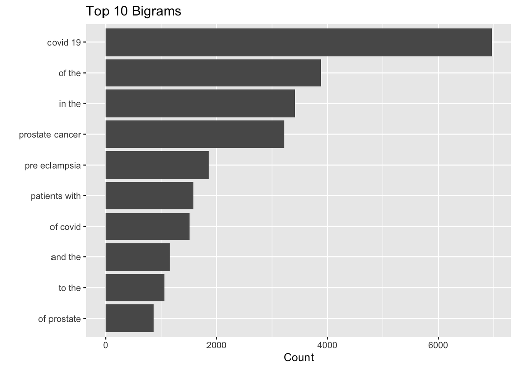

```r
bigrams <- pubmed |>
  unnest_tokens(bigram, abstract, token = "ngrams", n = 2) # Tokenize abstract into bigrams

top_bigrams <- bigrams |>
  count(bigram, sort = TRUE) |>
  slice_max(n, n = 10)

top_bigrams |>
  ggplot(aes(x = reorder(bigram, n), y = n)) +
  geom_col() +
  coord_flip() +
  labs(title = "Top 10 Bigrams", x = "", y = "Count")
```

### Question 4 (15 points)

**Calculate the TF-IDF value for each word-search term combination (here you want the search term to be the “document”). What are the 5 tokens from each search term with the highest TF-IDF value?** The top five tokens with the highest TF–IDF values for each search term are closely related to the corresponding disease and reflect key characteristics of that condition.

**How are the results different from the answers you got in Question 1?** The results differ substantially from those in Question 1, where word frequency alone was examined. In that analysis, the most frequent tokens were primarily stop words that appeared across many abstracts. In contrast, the TF–IDF results contain mostly disease-specific terms, and stop words do not appear among the top-ranked tokens.

This difference arises because TF–IDF emphasizes words that are distinctive to a particular document (a search term). TF–IDF accounts not only for term frequency (TF), defined as the frequency of a term in a document / the total number of words, but also for inverse document frequency (IDF), defined as log(total number of documents / number of documents containing the term) as a weight. Words that occur frequently across many documents, such as stop words, receive low IDF values (low weight) and therefore low TF–IDF scores (TF–IDF = TF × IDF). As a result, TF–IDF highlights terms that are more specific and informative for each search term.

```r
tfidf <- tokens |>
#  anti_join(stop_words, by = "word") |> # not necessary execpt the computational efficiency, because they will get very low IDFs meaning low weights in TF-IDF = TF*IDF
  count(term, word, sort = TRUE) |>
  bind_tf_idf(word, term, n) # bind_tf_idf(word=token/term, term=document, n (document("search term)-term(words) pair" counts))
#tfidf

top_tfidf <- tfidf |>
  group_by(term) |>
  slice_max(tf_idf, n = 5)
kable(top_tfidf)
```

| term | word | n | tf | idf | tf_idf |
| --- | --- | --- | --- | --- | --- |
| covid | covid | 7275 | 0.0371050 | 1.6094379 | 0.0597183 |
| covid | pandemic | 800 | 0.0040803 | 1.6094379 | 0.0065670 |
| covid | coronavirus | 647 | 0.0032999 | 1.6094379 | 0.0053110 |
| covid | sars | 372 | 0.0018973 | 1.6094379 | 0.0030536 |
| covid | cov | 334 | 0.0017035 | 1.6094379 | 0.0027417 |
| cystic fibrosis | cf | 625 | 0.0127188 | 0.9162907 | 0.0116541 |
| cystic fibrosis | fibrosis | 867 | 0.0176435 | 0.5108256 | 0.0090127 |
| cystic fibrosis | cystic | 862 | 0.0175417 | 0.5108256 | 0.0089608 |
| cystic fibrosis | cftr | 86 | 0.0017501 | 1.6094379 | 0.0028167 |
| cystic fibrosis | sweat | 83 | 0.0016891 | 1.6094379 | 0.0027184 |
| meningitis | meningitis | 429 | 0.0091942 | 1.6094379 | 0.0147974 |
| meningitis | meningeal | 219 | 0.0046935 | 1.6094379 | 0.0075539 |
| meningitis | pachymeningitis | 149 | 0.0031933 | 1.6094379 | 0.0051394 |
| meningitis | csf | 206 | 0.0044149 | 0.9162907 | 0.0040453 |
| meningitis | meninges | 106 | 0.0022718 | 1.6094379 | 0.0036562 |
| preeclampsia | eclampsia | 2005 | 0.0142784 | 1.6094379 | 0.0229802 |
| preeclampsia | preeclampsia | 1863 | 0.0132672 | 1.6094379 | 0.0213527 |
| preeclampsia | pregnancy | 969 | 0.0069006 | 0.5108256 | 0.0035250 |
| preeclampsia | maternal | 797 | 0.0056757 | 0.5108256 | 0.0028993 |
| preeclampsia | gestational | 191 | 0.0013602 | 1.6094379 | 0.0021891 |
| prostate cancer | prostate | 3832 | 0.0311890 | 1.6094379 | 0.0501967 |
| prostate cancer | androgen | 305 | 0.0024824 | 1.6094379 | 0.0039953 |
| prostate cancer | psa | 282 | 0.0022952 | 1.6094379 | 0.0036940 |
| prostate cancer | prostatectomy | 215 | 0.0017499 | 1.6094379 | 0.0028164 |
| prostate cancer | castration | 148 | 0.0012046 | 1.6094379 | 0.0019387 |

## Sentiment Analysis

### Question 5 (20 points)

**Perform a sentiment analysis using the NRC lexicon.** The NRC Word–Emotion Association Lexicon classifies words into ten sentiment and emotion categories: positive, negative, anger, anticipation, disgust, fear, joy, sadness, surprise, and trust (Mohammad and Turney, 2013).

**What is the most common sentiment for each search term?** For each search term, the most frequent sentiment category is either “positive” or “negative”. Abstracts related to COVID, cystic fibrosis, and preeclampsia show “positive” as the most common sentiment, whereas meningitis and prostate cancer are most frequently associated with “negative” sentiment.

**What if you remove “positive” and “negative” from the list?** When the “positive” and “negative” categories are excluded, “fear” becomes the most common sentiment for COVID-19, meningitis, and prostate cancer. For cystic fibrosis, “disgust” is the most frequent category, while “anticipation” is most common for preeclampsia. These assignments are less straightforward to interpret, showing limitations of lexicon-based sentiment classification in biomedical text.

```r
sentiment_nrc <- tokens |>
  anti_join(stop_words, by = "word")  |>
  inner_join(get_sentiments("nrc"), by = "word", relationship = "many-to-many") |> # info from nrc and inner join between nrc and abstract.
  count(term, sentiment, sort = TRUE)

top_nrc <- sentiment_nrc |>
  group_by(term) |>
  slice_max(n, n=1)
kable(top_nrc)
```

| term | sentiment | n |
| --- | --- | --- |
| covid | positive | 9254 |
| cystic fibrosis | positive | 2564 |
| meningitis | negative | 1959 |
| preeclampsia | positive | 7603 |
| prostate cancer | negative | 8799 |

```r
sentiment_nrc_filtered <- sentiment_nrc |>
  filter(!sentiment %in% c("positive", "negative")) |>
  group_by(term) |>
  slice_max(n, n=1)
kable(sentiment_nrc_filtered)
```

| term | sentiment | n |
| --- | --- | --- |
| covid | fear | 7373 |
| cystic fibrosis | disgust | 1714 |
| meningitis | fear | 1371 |
| preeclampsia | anticipation | 4555 |
| prostate cancer | fear | 8039 |

### Question 6 (20 points)

**Now perform a sentiment analysis using the AFINN lexicon to get an average positivity score for each abstract (hint: you may want to create a variable that indexes, or counts, the abstracts).** Using the AFINN lexicon, each token is assigned a sentiment score ranging from −5 to 5, representing the magnitude of negative to positive sentiment (Nielsen, 2011).

**Create a visualization that shows these scores grouped by search term. Are any search terms noticeably different from the others?** Overall, the average sentiment scores for all search terms are close to neutral, generally ranging between approximately −0.5 and 0.5. One noticeable pattern is that the cystic fibrosis abstracts show a higher average sentiment score, approximately 0.5, whereas the other search terms have averages slightly below zero. In addition, the interquartile range for cystic fibrosis appears shifted toward the positive side (approximately −0.5 to 1.2), suggesting that some cystic fibrosis–specific terms are assigned positive sentiment values in the AFINN lexicon.

However, a formal statistical test would be required to determine whether the higher average sentiment score observed for cystic fibrosis is statistically significant compared with the other search terms.

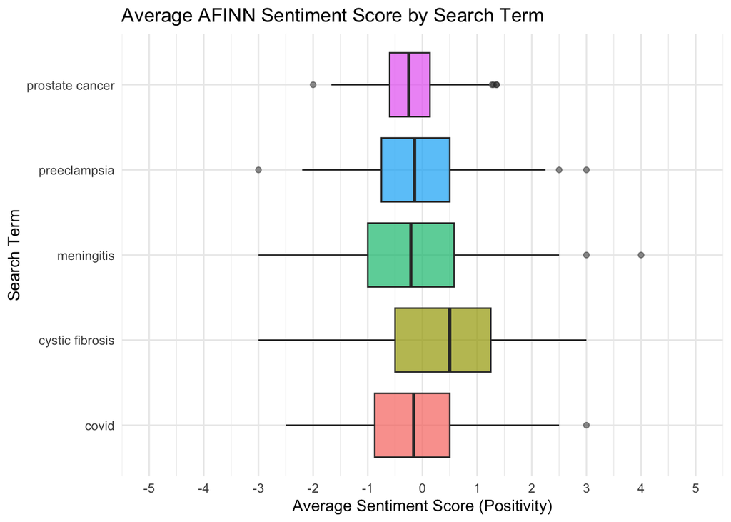

```r
pubmed_indexed <- pubmed |>
  mutate(id = row_number())

afinn_scores <- pubmed_indexed |>
  unnest_tokens(word, abstract) |>
  inner_join(get_sentiments("afinn"), by = "word") |>
  group_by(id, term) |>
  summarize(score = mean(value, na.rm = TRUE), .groups = "drop") # If use ".by", don't need to use .groups = "drop".

ggplot(afinn_scores, aes(x = term, y = score, fill = term)) +
  geom_boxplot(alpha = 0.7, outlier.alpha = 0.5) +
  scale_y_continuous(limits = c(-5, 5), breaks = seq(-5, 5, by = 1)) +
  coord_flip() + # horizontal boxplot
  theme_minimal() +
  labs(
    title = "Average AFINN Sentiment Score by Search Term",
    x = "Search Term",
    y = "Average Sentiment Score (Positivity)"
  ) +
  theme(legend.position = "none")
```

## Reference

1. Saif M. Mohammad and Peter Turney. (2013), “Crowdsourcing a Word-Emotion Association Lexicon.” Computational Intelligence, 29(3): 436-465.
2. Finn Årup Nielsen (2011), “A new ANEW: Evaluation of a word list for sentiment analysis in microblogs.” Proceedings of the ESWC2011 Workshop on ‘Making Sense of Microposts’: Big things come in small packages 718 in CEUR Workshop Proceedings 93-98.
3. lexicon_nrc{textdata}, R documentation https://search.r-project.org/CRAN/refmans/textdata/html/lexicon_nrc.html)
4. lexicon_afinn {textdata}, R documentation https://search.r-project.org/CRAN/refmans/textdata/html/lexicon_afinn.html